# 加载数据

```
(60000, 28, 28)
```

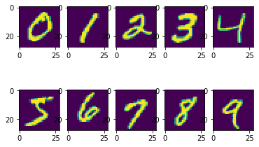

```python
from keras.datasets import mnist
(X0,Y0),(X1,Y1) = mnist.load_data(path="/clubear/datasets/mnist.npz")
print(X0.shape)
from matplotlib import pyplot as plt
plt.figure()
fig,ax = plt.subplots(2,5)
ax=ax.flatten()
for i in range(10):
    Im=X0[Y0==i][0]
    ax[i].imshow(Im)
plt.show()
```

# 数据处理

```python
from keras.utils import np_utils
#X0不能直接被Tensorflow处理因为缺少一个argument：通道数
N0=X0.shape[0];N1=X1.shape[0]
print([N0,N1])
X0 = X0.reshape(N0,28,28,1)/255
X1 = X1.reshape(N1,28,28,1)/255
#变成one_hot变量
YY0 = np_utils.to_categorical(Y0)
YY1 = np_utils.to_categorical(Y1)
YY1
```

```
[60000, 10000]
```

```
array([[0., 0., 0., ..., 1., 0., 0.],
       [0., 0., 1., ..., 0., 0., 0.],
       [0., 1., 0., ..., 0., 0., 0.],
       ...,
       [0., 0., 0., ..., 0., 0., 0.],
       [0., 0., 0., ..., 0., 0., 0.],
       [0., 0., 0., ..., 0., 0., 0.]], dtype=float32)
```

# LeNet5 模型搭建

```python
from keras.layers import Conv2D,Dense,Flatten,Input,MaxPooling2D,Dropout
from keras import Model

input_layer = Input([28,28,1])
x = input_layer
x = Conv2D(6,[5,5],padding = "same", activation = 'relu')(x)
x = MaxPooling2D(pool_size = [2,2], strides = [2,2])(x)
x = Conv2D(16,[5,5],padding = "valid", activation = 'relu')(x)
x = MaxPooling2D(pool_size = [2,2], strides = [2,2])(x)
x = Flatten()(x)
x = Dense(120,activation = 'relu')(x)
x = Dense(84,activation = 'relu')(x)
x = Dense(10,activation = 'softmax')(x)
output_layer=x
model=Model(input_layer,output_layer)
model.summary()
```

```
Model: "model_2"
_________________________________________________________________
Layer (type)                 Output Shape              Param #
=================================================================
input_2 (InputLayer)         (None, 28, 28, 1)         0
_________________________________________________________________
conv2d_3 (Conv2D)            (None, 28, 28, 6)         156
_________________________________________________________________
max_pooling2d_3 (MaxPooling2 (None, 14, 14, 6)         0
_________________________________________________________________
conv2d_4 (Conv2D)            (None, 10, 10, 16)        2416
_________________________________________________________________
max_pooling2d_4 (MaxPooling2 (None, 5, 5, 16)          0
_________________________________________________________________
flatten_2 (Flatten)          (None, 400)               0
_________________________________________________________________
dense_4 (Dense)              (None, 120)               48120
_________________________________________________________________
dense_5 (Dense)              (None, 84)                10164
_________________________________________________________________
dense_6 (Dense)              (None, 10)                850
=================================================================
Total params: 61,706
Trainable params: 61,706
Non-trainable params: 0
_________________________________________________________________
```

## 模型和参数解释

第一层input layer，规定input只能是 [28,28,1] 的矩阵，无参数。  
第二层conv2D： （5 *5* 1+1） *6 = 26* 6 = 156, 其中5 5是kernel size，1是上一层遗留通道数，6是卷积核个数。  
第三层池化使用 [2,2] 矩形，步长行列都是2 （没有1 1tensor被重复池化），没有学习项，无参数  
第四层conv2D: （5 *5* 6 + 1） *16 = 129* 16 = 2416, 其中5 5是kernel size，6是上一层遗留通道数，16是卷积核个数。  
第五层池化使用 [2,2] 矩形，步长行列都是2 （没有1 1 tensor被重复池化），没有学习项，无参数

第六层压扁，无参数

第七层Dense：（hidden） 400 120 + 120 = 48000 +120 = 48120  
第八层Dense： (hidden） 120 84 + 84 = 10080 +84 = 10164  
第九层Dense： 84 * 10 + 10 = 840 +10 = 850

所以总共有61706个参数。

# LeNet5 编译运行

```python
model.compile(loss = 'categorical_crossentropy',optimizer='adam',metrics = ['accuracy'])
model.fit(X0,YY0,epochs = 10,batch_size = 200,validation_data=[X1,YY1])
```

```
Train on 60000 samples, validate on 10000 samples
```

```
<keras.callbacks.callbacks.History at 0x7f48702093d0>
```

# 改进？变形？